# Risk Factor Analysis

## Outcome Variable

**Outcome Variable:** ever_stunted

## Predictor Variables

**Intervention Variable:** birthwt

**Adjustment Set:**

- arm
- sex
- W_mage
- meducyrs
- feducyrs
- vagbrth
- single
- brthmon
- W_parity
- delta_W_mage
- delta_meducyrs
- delta_feducyrs
- delta_vagbrth
- delta_single
- delta_brthmon
- delta_W_parity

## Stratifying Variables

The analysis was stratified on these variable(s):

- agecat
- studyid
- country

## Data Summary

| agecat | studyid | country | birthwt | ever_stunted | n_cell | n |
| --- | --- | --- | --- | --- | --- | --- |
| 0-24 months (no birth st.) | CMC-V-BCS-2002 | INDIA | Normal or high birthweight | 0 | 27 | 290 |
| 0-24 months (no birth st.) | CMC-V-BCS-2002 | INDIA | Normal or high birthweight | 1 | 249 | 290 |
| 0-24 months (no birth st.) | CMC-V-BCS-2002 | INDIA | Low birthweight | 0 | 1 | 290 |
| 0-24 months (no birth st.) | CMC-V-BCS-2002 | INDIA | Low birthweight | 1 | 13 | 290 |
| 0-24 months (no birth st.) | CMIN | BANGLADESH | Normal or high birthweight | 0 | 7 | 17 |
| 0-24 months (no birth st.) | CMIN | BANGLADESH | Normal or high birthweight | 1 | 6 | 17 |
| 0-24 months (no birth st.) | CMIN | BANGLADESH | Low birthweight | 0 | 3 | 17 |
| 0-24 months (no birth st.) | CMIN | BANGLADESH | Low birthweight | 1 | 1 | 17 |
| 0-24 months (no birth st.) | COHORTS | GUATEMALA | Normal or high birthweight | 0 | 232 | 833 |
| 0-24 months (no birth st.) | COHORTS | GUATEMALA | Normal or high birthweight | 1 | 555 | 833 |
| 0-24 months (no birth st.) | COHORTS | GUATEMALA | Low birthweight | 0 | 6 | 833 |
| 0-24 months (no birth st.) | COHORTS | GUATEMALA | Low birthweight | 1 | 40 | 833 |
| 0-24 months (no birth st.) | COHORTS | INDIA | Normal or high birthweight | 0 | 3828 | 5963 |
| 0-24 months (no birth st.) | COHORTS | INDIA | Normal or high birthweight | 1 | 1337 | 5963 |
| 0-24 months (no birth st.) | COHORTS | INDIA | Low birthweight | 0 | 434 | 5963 |
| 0-24 months (no birth st.) | COHORTS | INDIA | Low birthweight | 1 | 364 | 5963 |
| 0-24 months (no birth st.) | COHORTS | PHILIPPINES | Normal or high birthweight | 0 | 914 | 2830 |
| 0-24 months (no birth st.) | COHORTS | PHILIPPINES | Normal or high birthweight | 1 | 1735 | 2830 |
| 0-24 months (no birth st.) | COHORTS | PHILIPPINES | Low birthweight | 0 | 35 | 2830 |
| 0-24 months (no birth st.) | COHORTS | PHILIPPINES | Low birthweight | 1 | 146 | 2830 |
| 0-24 months (no birth st.) | CONTENT | PERU | Normal or high birthweight | 0 | 1 | 2 |
| 0-24 months (no birth st.) | CONTENT | PERU | Normal or high birthweight | 1 | 1 | 2 |
| 0-24 months (no birth st.) | CONTENT | PERU | Low birthweight | 0 | 0 | 2 |
| 0-24 months (no birth st.) | CONTENT | PERU | Low birthweight | 1 | 0 | 2 |
| 0-24 months (no birth st.) | EE | PAKISTAN | Normal or high birthweight | 0 | 39 | 213 |
| 0-24 months (no birth st.) | EE | PAKISTAN | Normal or high birthweight | 1 | 136 | 213 |
| 0-24 months (no birth st.) | EE | PAKISTAN | Low birthweight | 0 | 2 | 213 |
| 0-24 months (no birth st.) | EE | PAKISTAN | Low birthweight | 1 | 36 | 213 |
| 0-24 months (no birth st.) | GMS-Nepal | NEPAL | Normal or high birthweight | 0 | 212 | 575 |
| 0-24 months (no birth st.) | GMS-Nepal | NEPAL | Normal or high birthweight | 1 | 231 | 575 |

[output cut: 186 more lines]

The following strata were considered:

- agecat: 0-24 months (no birth st.), studyid: CMC-V-BCS-2002, country: INDIA
- agecat: 0-24 months (no birth st.), studyid: CMIN, country: BANGLADESH
- agecat: 0-24 months (no birth st.), studyid: COHORTS, country: GUATEMALA
- agecat: 0-24 months (no birth st.), studyid: COHORTS, country: INDIA
- agecat: 0-24 months (no birth st.), studyid: COHORTS, country: PHILIPPINES
- agecat: 0-24 months (no birth st.), studyid: CONTENT, country: PERU
- agecat: 0-24 months (no birth st.), studyid: EE, country: PAKISTAN
- agecat: 0-24 months (no birth st.), studyid: GMS-Nepal, country: NEPAL
- agecat: 0-24 months (no birth st.), studyid: IRC, country: INDIA
- agecat: 0-24 months (no birth st.), studyid: JiVitA-3, country: BANGLADESH
- agecat: 0-24 months (no birth st.), studyid: JiVitA-4, country: BANGLADESH
- agecat: 0-24 months (no birth st.), studyid: Keneba, country: GAMBIA
- agecat: 0-24 months (no birth st.), studyid: MAL-ED, country: BANGLADESH
- agecat: 0-24 months (no birth st.), studyid: MAL-ED, country: BRAZIL
- agecat: 0-24 months (no birth st.), studyid: MAL-ED, country: INDIA
- agecat: 0-24 months (no birth st.), studyid: MAL-ED, country: NEPAL
- agecat: 0-24 months (no birth st.), studyid: MAL-ED, country: PERU
- agecat: 0-24 months (no birth st.), studyid: MAL-ED, country: SOUTH AFRICA
- agecat: 0-24 months (no birth st.), studyid: MAL-ED, country: TANZANIA, UNITED REPUBLIC OF
- agecat: 0-24 months (no birth st.), studyid: NIH-Birth, country: BANGLADESH
- agecat: 0-24 months (no birth st.), studyid: NIH-Crypto, country: BANGLADESH
- agecat: 0-24 months (no birth st.), studyid: PROBIT, country: BELARUS
- agecat: 0-24 months (no birth st.), studyid: PROVIDE, country: BANGLADESH
- agecat: 0-24 months (no birth st.), studyid: ResPak, country: PAKISTAN
- agecat: 0-24 months (no birth st.), studyid: SAS-CompFeed, country: INDIA
- agecat: 0-24 months (no birth st.), studyid: TanzaniaChild2, country: TANZANIA, UNITED REPUBLIC OF
- agecat: 0-24 months (no birth st.), studyid: ZVITAMBO, country: ZIMBABWE
- agecat: 0-6 months (no birth st.), studyid: CMC-V-BCS-2002, country: INDIA
- agecat: 0-6 months (no birth st.), studyid: CMIN, country: BANGLADESH
- agecat: 0-6 months (no birth st.), studyid: COHORTS, country: GUATEMALA
- agecat: 0-6 months (no birth st.), studyid: COHORTS, country: INDIA
- agecat: 0-6 months (no birth st.), studyid: COHORTS, country: PHILIPPINES
- agecat: 0-6 months (no birth st.), studyid: CONTENT, country: PERU
- agecat: 0-6 months (no birth st.), studyid: EE, country: PAKISTAN
- agecat: 0-6 months (no birth st.), studyid: GMS-Nepal, country: NEPAL
- agecat: 0-6 months (no birth st.), studyid: IRC, country: INDIA
- agecat: 0-6 months (no birth st.), studyid: JiVitA-3, country: BANGLADESH
- agecat: 0-6 months (no birth st.), studyid: JiVitA-4, country: BANGLADESH
- agecat: 0-6 months (no birth st.), studyid: Keneba, country: GAMBIA
- agecat: 0-6 months (no birth st.), studyid: MAL-ED, country: BANGLADESH
- agecat: 0-6 months (no birth st.), studyid: MAL-ED, country: BRAZIL
- agecat: 0-6 months (no birth st.), studyid: MAL-ED, country: INDIA
- agecat: 0-6 months (no birth st.), studyid: MAL-ED, country: NEPAL
- agecat: 0-6 months (no birth st.), studyid: MAL-ED, country: PERU
- agecat: 0-6 months (no birth st.), studyid: MAL-ED, country: SOUTH AFRICA
- agecat: 0-6 months (no birth st.), studyid: MAL-ED, country: TANZANIA, UNITED REPUBLIC OF
- agecat: 0-6 months (no birth st.), studyid: NIH-Birth, country: BANGLADESH
- agecat: 0-6 months (no birth st.), studyid: NIH-Crypto, country: BANGLADESH
- agecat: 0-6 months (no birth st.), studyid: PROBIT, country: BELARUS
- agecat: 0-6 months (no birth st.), studyid: PROVIDE, country: BANGLADESH
- agecat: 0-6 months (no birth st.), studyid: ResPak, country: PAKISTAN
- agecat: 0-6 months (no birth st.), studyid: SAS-CompFeed, country: INDIA
- agecat: 0-6 months (no birth st.), studyid: TanzaniaChild2, country: TANZANIA, UNITED REPUBLIC OF
- agecat: 0-6 months (no birth st.), studyid: ZVITAMBO, country: ZIMBABWE

### Dropped Strata

Some strata were dropped due to rare outcomes:

- agecat: 0-24 months (no birth st.), studyid: CMC-V-BCS-2002, country: INDIA
- agecat: 0-24 months (no birth st.), studyid: CMIN, country: BANGLADESH
- agecat: 0-24 months (no birth st.), studyid: CONTENT, country: PERU
- agecat: 0-24 months (no birth st.), studyid: EE, country: PAKISTAN
- agecat: 0-24 months (no birth st.), studyid: MAL-ED, country: BRAZIL
- agecat: 0-24 months (no birth st.), studyid: MAL-ED, country: NEPAL
- agecat: 0-24 months (no birth st.), studyid: MAL-ED, country: PERU
- agecat: 0-24 months (no birth st.), studyid: MAL-ED, country: SOUTH AFRICA
- agecat: 0-24 months (no birth st.), studyid: MAL-ED, country: TANZANIA, UNITED REPUBLIC OF
- agecat: 0-24 months (no birth st.), studyid: PROBIT, country: BELARUS
- agecat: 0-24 months (no birth st.), studyid: ResPak, country: PAKISTAN
- agecat: 0-6 months (no birth st.), studyid: CMC-V-BCS-2002, country: INDIA
- agecat: 0-6 months (no birth st.), studyid: CMIN, country: BANGLADESH
- agecat: 0-6 months (no birth st.), studyid: CONTENT, country: PERU
- agecat: 0-6 months (no birth st.), studyid: MAL-ED, country: BRAZIL
- agecat: 0-6 months (no birth st.), studyid: MAL-ED, country: NEPAL
- agecat: 0-6 months (no birth st.), studyid: MAL-ED, country: PERU
- agecat: 0-6 months (no birth st.), studyid: MAL-ED, country: SOUTH AFRICA
- agecat: 0-6 months (no birth st.), studyid: MAL-ED, country: TANZANIA, UNITED REPUBLIC OF
- agecat: 0-6 months (no birth st.), studyid: PROBIT, country: BELARUS
- agecat: 0-6 months (no birth st.), studyid: ResPak, country: PAKISTAN

## Methods Detail

We're interested in the causal parameters $E[Y_a]$ for all values of $a \in \mathcal{A}$. These parameters represent the mean outcome if, possibly contrary to fact, we intervened to set all units to have $A=a$. Under the randomization and positivity assumptions, these are identified by the statistical parameters $\psi_a=E_W[E_{Y|A,W}(Y|A=a,W)]$. In addition, we're interested in the mean of $Y$, $E[Y]$ under no intervention (the observed mean). We will estimate these parameters by using SuperLearner to fit the relevant likelihood factors -- $E_{Y|A,W}(Y|A=a,W)$ and $p(A=a|W)$, and then updating our likelihood fit using a joint TMLE.

For unadjusted analyses ($W=\{\}$), initial likelihoods were estimated using Lrnr_glm to estimate the simple $E(Y|A)$ and Lrnr_mean to estimate $p(A)$. For adjusted analyses, a small library containing Lrnr_glmnet, Lrnr_xgboost, and Lrnr_mean was used.

Having estimated these parameters, we will then use the delta method to estimate relative risks and attributable risks relative to a prespecified baseline level of $A$.

# Results Detail

## Results Plots

[figure not shown]

[figure not shown]

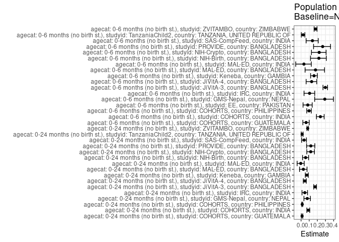

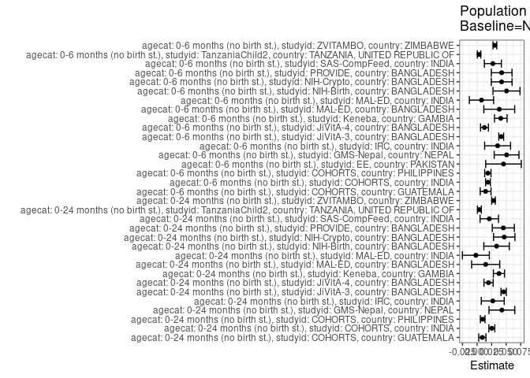

## Results Table

### Parameter: TSM

| agecat | studyid | country | intervention_level | baseline_level | estimate | ci_lower | ci_upper |
| --- | --- | --- | --- | --- | --- | --- | --- |
| 0-24 months (no birth st.) | COHORTS | GUATEMALA | Normal or high birthweight | NA | 0.7052097 | 0.6733356 | 0.7370837 |
| 0-24 months (no birth st.) | COHORTS | GUATEMALA | Low birthweight | NA | 0.8695652 | 0.7721834 | 0.9669470 |
| 0-24 months (no birth st.) | COHORTS | INDIA | Normal or high birthweight | NA | 0.2599001 | 0.2479801 | 0.2718201 |
| 0-24 months (no birth st.) | COHORTS | INDIA | Low birthweight | NA | 0.4518130 | 0.4174023 | 0.4862237 |
| 0-24 months (no birth st.) | COHORTS | PHILIPPINES | Normal or high birthweight | NA | 0.6549820 | 0.6369150 | 0.6730491 |
| 0-24 months (no birth st.) | COHORTS | PHILIPPINES | Low birthweight | NA | 0.8063655 | 0.7502289 | 0.8625021 |
| 0-24 months (no birth st.) | GMS-Nepal | NEPAL | Normal or high birthweight | NA | 0.5191319 | 0.4725364 | 0.5657274 |
| 0-24 months (no birth st.) | GMS-Nepal | NEPAL | Low birthweight | NA | 0.7022571 | 0.6222388 | 0.7822753 |
| 0-24 months (no birth st.) | IRC | INDIA | Normal or high birthweight | NA | 0.5617533 | 0.5061612 | 0.6173454 |
| 0-24 months (no birth st.) | IRC | INDIA | Low birthweight | NA | 0.6778348 | 0.5569424 | 0.7987272 |
| 0-24 months (no birth st.) | JiVitA-3 | BANGLADESH | Normal or high birthweight | NA | 0.2194061 | 0.2108620 | 0.2279501 |
| 0-24 months (no birth st.) | JiVitA-3 | BANGLADESH | Low birthweight | NA | 0.4239739 | 0.4054980 | 0.4424498 |
| 0-24 months (no birth st.) | JiVitA-4 | BANGLADESH | Normal or high birthweight | NA | 0.4085674 | 0.3869514 | 0.4301835 |
| 0-24 months (no birth st.) | JiVitA-4 | BANGLADESH | Low birthweight | NA | 0.5758559 | 0.5107440 | 0.6409679 |
| 0-24 months (no birth st.) | Keneba | GAMBIA | Normal or high birthweight | NA | 0.4929962 | 0.4655824 | 0.5204100 |
| 0-24 months (no birth st.) | Keneba | GAMBIA | Low birthweight | NA | 0.7793799 | 0.7171985 | 0.8415614 |
| 0-24 months (no birth st.) | MAL-ED | BANGLADESH | Normal or high birthweight | NA | 0.5132275 | 0.4418022 | 0.5846528 |
| 0-24 months (no birth st.) | MAL-ED | BANGLADESH | Low birthweight | NA | 0.6400000 | 0.4514023 | 0.8285977 |
| 0-24 months (no birth st.) | MAL-ED | INDIA | Normal or high birthweight | NA | 0.5360414 | 0.4639191 | 0.6081637 |
| 0-24 months (no birth st.) | MAL-ED | INDIA | Low birthweight | NA | 0.5118676 | 0.2798701 | 0.7438651 |
| 0-24 months (no birth st.) | NIH-Birth | BANGLADESH | Normal or high birthweight | NA | 0.5672640 | 0.5184398 | 0.6160882 |
| 0-24 months (no birth st.) | NIH-Birth | BANGLADESH | Low birthweight | NA | 0.7188138 | 0.6354088 | 0.8022188 |
| 0-24 months (no birth st.) | NIH-Crypto | BANGLADESH | Normal or high birthweight | NA | 0.3468728 | 0.3067936 | 0.3869520 |
| 0-24 months (no birth st.) | NIH-Crypto | BANGLADESH | Low birthweight | NA | 0.6184899 | 0.5299175 | 0.7070624 |
| 0-24 months (no birth st.) | PROVIDE | BANGLADESH | Normal or high birthweight | NA | 0.3309247 | 0.2905388 | 0.3713105 |
| 0-24 months (no birth st.) | PROVIDE | BANGLADESH | Low birthweight | NA | 0.6002925 | 0.5095124 | 0.6910726 |
| 0-24 months (no birth st.) | SAS-CompFeed | INDIA | Normal or high birthweight | NA | 0.5451656 | 0.4797301 | 0.6106011 |
| 0-24 months (no birth st.) | SAS-CompFeed | INDIA | Low birthweight | NA | 0.7411289 | 0.6344593 | 0.8477985 |
| 0-24 months (no birth st.) | TanzaniaChild2 | TANZANIA, UNITED REPUBLIC OF | Normal or high birthweight | NA | 0.2945068 | 0.2751792 | 0.3138344 |
| 0-24 months (no birth st.) | TanzaniaChild2 | TANZANIA, UNITED REPUBLIC OF | Low birthweight | NA | 0.4879640 | 0.3717451 | 0.6041828 |
| 0-24 months (no birth st.) | ZVITAMBO | ZIMBABWE | Normal or high birthweight | NA | 0.3204544 | 0.3118803 | 0.3290285 |
| 0-24 months (no birth st.) | ZVITAMBO | ZIMBABWE | Low birthweight | NA | 0.6248106 | 0.5972112 | 0.6524099 |
| 0-6 months (no birth st.) | COHORTS | GUATEMALA | Normal or high birthweight | NA | 0.2224633 | 0.1930181 | 0.2519085 |
| 0-6 months (no birth st.) | COHORTS | GUATEMALA | Low birthweight | NA | 0.4996735 | 0.3498178 | 0.6495291 |
| 0-6 months (no birth st.) | COHORTS | INDIA | Normal or high birthweight | NA | 0.0601256 | 0.0535723 | 0.0666790 |
| 0-6 months (no birth st.) | COHORTS | INDIA | Low birthweight | NA | 0.2005175 | 0.1722660 | 0.2287691 |
| 0-6 months (no birth st.) | COHORTS | PHILIPPINES | Normal or high birthweight | NA | 0.1701597 | 0.1558516 | 0.1844679 |
| 0-6 months (no birth st.) | COHORTS | PHILIPPINES | Low birthweight | NA | 0.4600437 | 0.3874782 | 0.5326091 |
| 0-6 months (no birth st.) | EE | PAKISTAN | Normal or high birthweight | NA | 0.5085714 | 0.4343282 | 0.5828147 |
| 0-6 months (no birth st.) | EE | PAKISTAN | Low birthweight | NA | 0.7631579 | 0.6276655 | 0.8986503 |
| 0-6 months (no birth st.) | GMS-Nepal | NEPAL | Normal or high birthweight | NA | 0.1232213 | 0.0924620 | 0.1539806 |
| 0-6 months (no birth st.) | GMS-Nepal | NEPAL | Low birthweight | NA | 0.3490174 | 0.2663626 | 0.4316722 |
| 0-6 months (no birth st.) | IRC | INDIA | Normal or high birthweight | NA | 0.3027550 | 0.2512281 | 0.3542820 |
| 0-6 months (no birth st.) | IRC | INDIA | Low birthweight | NA | 0.5952323 | 0.4512335 | 0.7392312 |
| 0-6 months (no birth st.) | JiVitA-3 | BANGLADESH | Normal or high birthweight | NA | 0.0977375 | 0.0917029 | 0.1037720 |
| 0-6 months (no birth st.) | JiVitA-3 | BANGLADESH | Low birthweight | NA | 0.2802304 | 0.2636647 | 0.2967961 |
| 0-6 months (no birth st.) | JiVitA-4 | BANGLADESH | Normal or high birthweight | NA | 0.0852773 | 0.0731115 | 0.0974431 |
| 0-6 months (no birth st.) | JiVitA-4 | BANGLADESH | Low birthweight | NA | 0.1940921 | 0.1394926 | 0.2486916 |
| 0-6 months (no birth st.) | Keneba | GAMBIA | Normal or high birthweight | NA | 0.2149282 | 0.1923619 | 0.2374946 |
| 0-6 months (no birth st.) | Keneba | GAMBIA | Low birthweight | NA | 0.5326231 | 0.4583691 | 0.6068771 |
| 0-6 months (no birth st.) | MAL-ED | BANGLADESH | Normal or high birthweight | NA | 0.1768432 | 0.1225919 | 0.2310944 |
| 0-6 months (no birth st.) | MAL-ED | BANGLADESH | Low birthweight | NA | 0.5233211 | 0.3300892 | 0.7165530 |
| 0-6 months (no birth st.) | MAL-ED | INDIA | Normal or high birthweight | NA | 0.2108108 | 0.1518917 | 0.2697299 |
| 0-6 months (no birth st.) | MAL-ED | INDIA | Low birthweight | NA | 0.2857143 | 0.0920288 | 0.4793998 |
| 0-6 months (no birth st.) | NIH-Birth | BANGLADESH | Normal or high birthweight | NA | 0.1803467 | 0.1427206 | 0.2179729 |
| 0-6 months (no birth st.) | NIH-Birth | BANGLADESH | Low birthweight | NA | 0.3889999 | 0.2973374 | 0.4806625 |
| 0-6 months (no birth st.) | NIH-Crypto | BANGLADESH | Normal or high birthweight | NA | 0.1476357 | 0.1176894 | 0.1775820 |
| 0-6 months (no birth st.) | NIH-Crypto | BANGLADESH | Low birthweight | NA | 0.3786236 | 0.2890549 | 0.4681922 |
| 0-6 months (no birth st.) | PROVIDE | BANGLADESH | Normal or high birthweight | NA | 0.1172823 | 0.0896714 | 0.1448932 |
| 0-6 months (no birth st.) | PROVIDE | BANGLADESH | Low birthweight | NA | 0.3677098 | 0.2770119 | 0.4584078 |
| 0-6 months (no birth st.) | SAS-CompFeed | INDIA | Normal or high birthweight | NA | 0.1673214 | 0.1411224 | 0.1935203 |
| 0-6 months (no birth st.) | SAS-CompFeed | INDIA | Low birthweight | NA | 0.4129493 | 0.3109046 | 0.5149941 |
| 0-6 months (no birth st.) | TanzaniaChild2 | TANZANIA, UNITED REPUBLIC OF | Normal or high birthweight | NA | 0.1322671 | 0.1179239 | 0.1466103 |
| 0-6 months (no birth st.) | TanzaniaChild2 | TANZANIA, UNITED REPUBLIC OF | Low birthweight | NA | 0.3138418 | 0.2054994 | 0.4221842 |
| 0-6 months (no birth st.) | ZVITAMBO | ZIMBABWE | Normal or high birthweight | NA | 0.1410337 | 0.1346297 | 0.1474376 |
| 0-6 months (no birth st.) | ZVITAMBO | ZIMBABWE | Low birthweight | NA | 0.4723013 | 0.4440262 | 0.5005764 |

### Parameter: E(Y)

| agecat | studyid | country | intervention_level | baseline_level | estimate | ci_lower | ci_upper |
| --- | --- | --- | --- | --- | --- | --- | --- |
| 0-24 months (no birth st.) | COHORTS | GUATEMALA | NA | NA | 0.7142857 | 0.6835892 | 0.7449822 |
| 0-24 months (no birth st.) | COHORTS | INDIA | NA | NA | 0.2852591 | 0.2737975 | 0.2967207 |
| 0-24 months (no birth st.) | COHORTS | PHILIPPINES | NA | NA | 0.6646643 | 0.6472674 | 0.6820612 |
| 0-24 months (no birth st.) | GMS-Nepal | NEPAL | NA | NA | 0.5617391 | 0.5211485 | 0.6023298 |
| 0-24 months (no birth st.) | IRC | INDIA | NA | NA | 0.5887324 | 0.5374737 | 0.6399911 |
| 0-24 months (no birth st.) | JiVitA-3 | BANGLADESH | NA | NA | 0.2650736 | 0.2569178 | 0.2732295 |
| 0-24 months (no birth st.) | JiVitA-4 | BANGLADESH | NA | NA | 0.4282588 | 0.4077731 | 0.4487445 |
| 0-24 months (no birth st.) | Keneba | GAMBIA | NA | NA | 0.5305842 | 0.5049322 | 0.5562362 |
| 0-24 months (no birth st.) | MAL-ED | BANGLADESH | NA | NA | 0.5280374 | 0.4609958 | 0.5950790 |
| 0-24 months (no birth st.) | MAL-ED | INDIA | NA | NA | 0.5339806 | 0.4656939 | 0.6022672 |
| 0-24 months (no birth st.) | NIH-Birth | BANGLADESH | NA | NA | 0.6007828 | 0.5582791 | 0.6432864 |
| 0-24 months (no birth st.) | NIH-Crypto | BANGLADESH | NA | NA | 0.3935681 | 0.3560687 | 0.4310676 |
| 0-24 months (no birth st.) | PROVIDE | BANGLADESH | NA | NA | 0.3759874 | 0.3382238 | 0.4137509 |
| 0-24 months (no birth st.) | SAS-CompFeed | INDIA | NA | NA | 0.5661425 | 0.5076572 | 0.6246278 |
| 0-24 months (no birth st.) | TanzaniaChild2 | TANZANIA, UNITED REPUBLIC OF | NA | NA | 0.2985075 | 0.2794291 | 0.3175858 |
| 0-24 months (no birth st.) | ZVITAMBO | ZIMBABWE | NA | NA | 0.3487372 | 0.3403993 | 0.3570750 |
| 0-6 months (no birth st.) | COHORTS | GUATEMALA | NA | NA | 0.2371007 | 0.2078658 | 0.2663357 |
| 0-6 months (no birth st.) | COHORTS | INDIA | NA | NA | 0.0788439 | 0.0719356 | 0.0857521 |
| 0-6 months (no birth st.) | COHORTS | PHILIPPINES | NA | NA | 0.1886926 | 0.1742747 | 0.2031105 |
| 0-6 months (no birth st.) | EE | PAKISTAN | NA | NA | 0.5539906 | 0.4870787 | 0.6209025 |
| 0-6 months (no birth st.) | GMS-Nepal | NEPAL | NA | NA | 0.1739130 | 0.1429052 | 0.2049209 |
| 0-6 months (no birth st.) | IRC | INDIA | NA | NA | 0.3380282 | 0.2887514 | 0.3873050 |
| 0-6 months (no birth st.) | JiVitA-3 | BANGLADESH | NA | NA | 0.1391999 | 0.1330990 | 0.1453008 |
| 0-6 months (no birth st.) | JiVitA-4 | BANGLADESH | NA | NA | 0.0979962 | 0.0852560 | 0.1107365 |
| 0-6 months (no birth st.) | Keneba | GAMBIA | NA | NA | 0.2556701 | 0.2332474 | 0.2780928 |
| 0-6 months (no birth st.) | MAL-ED | BANGLADESH | NA | NA | 0.2149533 | 0.1597864 | 0.2701201 |
| 0-6 months (no birth st.) | MAL-ED | INDIA | NA | NA | 0.2184466 | 0.1618848 | 0.2750084 |
| 0-6 months (no birth st.) | NIH-Birth | BANGLADESH | NA | NA | 0.2309198 | 0.1943452 | 0.2674943 |
| 0-6 months (no birth st.) | NIH-Crypto | BANGLADESH | NA | NA | 0.1898928 | 0.1597870 | 0.2199986 |
| 0-6 months (no birth st.) | PROVIDE | BANGLADESH | NA | NA | 0.1595577 | 0.1310079 | 0.1881074 |
| 0-6 months (no birth st.) | SAS-CompFeed | INDIA | NA | NA | 0.1944444 | 0.1700545 | 0.2188344 |
| 0-6 months (no birth st.) | TanzaniaChild2 | TANZANIA, UNITED REPUBLIC OF | NA | NA | 0.1356852 | 0.1214076 | 0.1499628 |
| 0-6 months (no birth st.) | ZVITAMBO | ZIMBABWE | NA | NA | 0.1716108 | 0.1650114 | 0.1782103 |

### Parameter: RR

| agecat | studyid | country | intervention_level | baseline_level | estimate | ci_lower | ci_upper |
| --- | --- | --- | --- | --- | --- | --- | --- |
| 0-24 months (no birth st.) | COHORTS | GUATEMALA | Normal or high birthweight | Normal or high birthweight | 1.000000 | 1.0000000 | 1.000000 |
| 0-24 months (no birth st.) | COHORTS | GUATEMALA | Low birthweight | Normal or high birthweight | 1.233059 | 1.0927880 | 1.391336 |
| 0-24 months (no birth st.) | COHORTS | INDIA | Normal or high birthweight | Normal or high birthweight | 1.000000 | 1.0000000 | 1.000000 |
| 0-24 months (no birth st.) | COHORTS | INDIA | Low birthweight | Normal or high birthweight | 1.738410 | 1.5915287 | 1.898847 |
| 0-24 months (no birth st.) | COHORTS | PHILIPPINES | Normal or high birthweight | Normal or high birthweight | 1.000000 | 1.0000000 | 1.000000 |
| 0-24 months (no birth st.) | COHORTS | PHILIPPINES | Low birthweight | Normal or high birthweight | 1.231126 | 1.1427829 | 1.326299 |
| 0-24 months (no birth st.) | GMS-Nepal | NEPAL | Normal or high birthweight | Normal or high birthweight | 1.000000 | 1.0000000 | 1.000000 |
| 0-24 months (no birth st.) | GMS-Nepal | NEPAL | Low birthweight | Normal or high birthweight | 1.352753 | 1.1700880 | 1.563934 |
| 0-24 months (no birth st.) | IRC | INDIA | Normal or high birthweight | Normal or high birthweight | 1.000000 | 1.0000000 | 1.000000 |
| 0-24 months (no birth st.) | IRC | INDIA | Low birthweight | Normal or high birthweight | 1.206641 | 0.9835109 | 1.480394 |
| 0-24 months (no birth st.) | JiVitA-3 | BANGLADESH | Normal or high birthweight | Normal or high birthweight | 1.000000 | 1.0000000 | 1.000000 |
| 0-24 months (no birth st.) | JiVitA-3 | BANGLADESH | Low birthweight | Normal or high birthweight | 1.932371 | 1.8256716 | 2.045306 |
| 0-24 months (no birth st.) | JiVitA-4 | BANGLADESH | Normal or high birthweight | Normal or high birthweight | 1.000000 | 1.0000000 | 1.000000 |
| 0-24 months (no birth st.) | JiVitA-4 | BANGLADESH | Low birthweight | Normal or high birthweight | 1.409451 | 1.2437891 | 1.597178 |
| 0-24 months (no birth st.) | Keneba | GAMBIA | Normal or high birthweight | Normal or high birthweight | 1.000000 | 1.0000000 | 1.000000 |
| 0-24 months (no birth st.) | Keneba | GAMBIA | Low birthweight | Normal or high birthweight | 1.580904 | 1.4350548 | 1.741577 |
| 0-24 months (no birth st.) | MAL-ED | BANGLADESH | Normal or high birthweight | Normal or high birthweight | 1.000000 | 1.0000000 | 1.000000 |
| 0-24 months (no birth st.) | MAL-ED | BANGLADESH | Low birthweight | Normal or high birthweight | 1.247010 | 0.9001943 | 1.727443 |
| 0-24 months (no birth st.) | MAL-ED | INDIA | Normal or high birthweight | Normal or high birthweight | 1.000000 | 1.0000000 | 1.000000 |
| 0-24 months (no birth st.) | MAL-ED | INDIA | Low birthweight | Normal or high birthweight | 0.954903 | 0.5949961 | 1.532514 |
| 0-24 months (no birth st.) | NIH-Birth | BANGLADESH | Normal or high birthweight | Normal or high birthweight | 1.000000 | 1.0000000 | 1.000000 |
| 0-24 months (no birth st.) | NIH-Birth | BANGLADESH | Low birthweight | Normal or high birthweight | 1.267159 | 1.0966574 | 1.464169 |
| 0-24 months (no birth st.) | NIH-Crypto | BANGLADESH | Normal or high birthweight | Normal or high birthweight | 1.000000 | 1.0000000 | 1.000000 |
| 0-24 months (no birth st.) | NIH-Crypto | BANGLADESH | Low birthweight | Normal or high birthweight | 1.783045 | 1.4857477 | 2.139832 |
| 0-24 months (no birth st.) | PROVIDE | BANGLADESH | Normal or high birthweight | Normal or high birthweight | 1.000000 | 1.0000000 | 1.000000 |
| 0-24 months (no birth st.) | PROVIDE | BANGLADESH | Low birthweight | Normal or high birthweight | 1.813985 | 1.4956755 | 2.200038 |
| 0-24 months (no birth st.) | SAS-CompFeed | INDIA | Normal or high birthweight | Normal or high birthweight | 1.000000 | 1.0000000 | 1.000000 |
| 0-24 months (no birth st.) | SAS-CompFeed | INDIA | Low birthweight | Normal or high birthweight | 1.359456 | 1.1269558 | 1.639924 |
| 0-24 months (no birth st.) | TanzaniaChild2 | TANZANIA, UNITED REPUBLIC OF | Normal or high birthweight | Normal or high birthweight | 1.000000 | 1.0000000 | 1.000000 |
| 0-24 months (no birth st.) | TanzaniaChild2 | TANZANIA, UNITED REPUBLIC OF | Low birthweight | Normal or high birthweight | 1.656885 | 1.2943656 | 2.120938 |
| 0-24 months (no birth st.) | ZVITAMBO | ZIMBABWE | Normal or high birthweight | Normal or high birthweight | 1.000000 | 1.0000000 | 1.000000 |
| 0-24 months (no birth st.) | ZVITAMBO | ZIMBABWE | Low birthweight | Normal or high birthweight | 1.949764 | 1.8518512 | 2.052855 |
| 0-6 months (no birth st.) | COHORTS | GUATEMALA | Normal or high birthweight | Normal or high birthweight | 1.000000 | 1.0000000 | 1.000000 |
| 0-6 months (no birth st.) | COHORTS | GUATEMALA | Low birthweight | Normal or high birthweight | 2.246094 | 1.6182385 | 3.117550 |
| 0-6 months (no birth st.) | COHORTS | INDIA | Normal or high birthweight | Normal or high birthweight | 1.000000 | 1.0000000 | 1.000000 |
| 0-6 months (no birth st.) | COHORTS | INDIA | Low birthweight | Normal or high birthweight | 3.334976 | 2.7920767 | 3.983439 |
| 0-6 months (no birth st.) | COHORTS | PHILIPPINES | Normal or high birthweight | Normal or high birthweight | 1.000000 | 1.0000000 | 1.000000 |
| 0-6 months (no birth st.) | COHORTS | PHILIPPINES | Low birthweight | Normal or high birthweight | 2.703599 | 2.2617676 | 3.231741 |
| 0-6 months (no birth st.) | EE | PAKISTAN | Normal or high birthweight | Normal or high birthweight | 1.000000 | 1.0000000 | 1.000000 |
| 0-6 months (no birth st.) | EE | PAKISTAN | Low birthweight | Normal or high birthweight | 1.500591 | 1.1924456 | 1.888367 |
| 0-6 months (no birth st.) | GMS-Nepal | NEPAL | Normal or high birthweight | Normal or high birthweight | 1.000000 | 1.0000000 | 1.000000 |
| 0-6 months (no birth st.) | GMS-Nepal | NEPAL | Low birthweight | Normal or high birthweight | 2.832444 | 2.0076016 | 3.996180 |
| 0-6 months (no birth st.) | IRC | INDIA | Normal or high birthweight | Normal or high birthweight | 1.000000 | 1.0000000 | 1.000000 |
| 0-6 months (no birth st.) | IRC | INDIA | Low birthweight | Normal or high birthweight | 1.966053 | 1.4623844 | 2.643192 |
| 0-6 months (no birth st.) | JiVitA-3 | BANGLADESH | Normal or high birthweight | Normal or high birthweight | 1.000000 | 1.0000000 | 1.000000 |
| 0-6 months (no birth st.) | JiVitA-3 | BANGLADESH | Low birthweight | Normal or high birthweight | 2.867175 | 2.6315792 | 3.123863 |
| 0-6 months (no birth st.) | JiVitA-4 | BANGLADESH | Normal or high birthweight | Normal or high birthweight | 1.000000 | 1.0000000 | 1.000000 |
| 0-6 months (no birth st.) | JiVitA-4 | BANGLADESH | Low birthweight | Normal or high birthweight | 2.276012 | 1.6613858 | 3.118018 |
| 0-6 months (no birth st.) | Keneba | GAMBIA | Normal or high birthweight | Normal or high birthweight | 1.000000 | 1.0000000 | 1.000000 |
| 0-6 months (no birth st.) | Keneba | GAMBIA | Low birthweight | Normal or high birthweight | 2.478144 | 2.0819920 | 2.949674 |
| 0-6 months (no birth st.) | MAL-ED | BANGLADESH | Normal or high birthweight | Normal or high birthweight | 1.000000 | 1.0000000 | 1.000000 |
| 0-6 months (no birth st.) | MAL-ED | BANGLADESH | Low birthweight | Normal or high birthweight | 2.959239 | 1.8477815 | 4.739247 |
| 0-6 months (no birth st.) | MAL-ED | INDIA | Normal or high birthweight | Normal or high birthweight | 1.000000 | 1.0000000 | 1.000000 |
| 0-6 months (no birth st.) | MAL-ED | INDIA | Low birthweight | Normal or high birthweight | 1.355311 | 0.6510151 | 2.821546 |
| 0-6 months (no birth st.) | NIH-Birth | BANGLADESH | Normal or high birthweight | Normal or high birthweight | 1.000000 | 1.0000000 | 1.000000 |
| 0-6 months (no birth st.) | NIH-Birth | BANGLADESH | Low birthweight | Normal or high birthweight | 2.156956 | 1.5773446 | 2.949551 |
| 0-6 months (no birth st.) | NIH-Crypto | BANGLADESH | Normal or high birthweight | Normal or high birthweight | 1.000000 | 1.0000000 | 1.000000 |
| 0-6 months (no birth st.) | NIH-Crypto | BANGLADESH | Low birthweight | Normal or high birthweight | 2.564580 | 1.8776364 | 3.502845 |
| 0-6 months (no birth st.) | PROVIDE | BANGLADESH | Normal or high birthweight | Normal or high birthweight | 1.000000 | 1.0000000 | 1.000000 |
| 0-6 months (no birth st.) | PROVIDE | BANGLADESH | Low birthweight | Normal or high birthweight | 3.135254 | 2.2315810 | 4.404866 |
| 0-6 months (no birth st.) | SAS-CompFeed | INDIA | Normal or high birthweight | Normal or high birthweight | 1.000000 | 1.0000000 | 1.000000 |
| 0-6 months (no birth st.) | SAS-CompFeed | INDIA | Low birthweight | Normal or high birthweight | 2.468001 | 1.8277346 | 3.332557 |
| 0-6 months (no birth st.) | TanzaniaChild2 | TANZANIA, UNITED REPUBLIC OF | Normal or high birthweight | Normal or high birthweight | 1.000000 | 1.0000000 | 1.000000 |
| 0-6 months (no birth st.) | TanzaniaChild2 | TANZANIA, UNITED REPUBLIC OF | Low birthweight | Normal or high birthweight | 2.372788 | 1.6525522 | 3.406926 |
| 0-6 months (no birth st.) | ZVITAMBO | ZIMBABWE | Normal or high birthweight | Normal or high birthweight | 1.000000 | 1.0000000 | 1.000000 |
| 0-6 months (no birth st.) | ZVITAMBO | ZIMBABWE | Low birthweight | Normal or high birthweight | 3.348855 | 3.1069726 | 3.609569 |

### Parameter: PAR

| agecat | studyid | country | intervention_level | baseline_level | estimate | ci_lower | ci_upper |
| --- | --- | --- | --- | --- | --- | --- | --- |
| 0-24 months (no birth st.) | COHORTS | GUATEMALA | Normal or high birthweight | NA | 0.0090761 | 0.0028693 | 0.0152828 |
| 0-24 months (no birth st.) | COHORTS | INDIA | Normal or high birthweight | NA | 0.0253590 | 0.0202699 | 0.0304480 |
| 0-24 months (no birth st.) | COHORTS | PHILIPPINES | Normal or high birthweight | NA | 0.0096823 | 0.0056866 | 0.0136779 |
| 0-24 months (no birth st.) | GMS-Nepal | NEPAL | Normal or high birthweight | NA | 0.0426072 | 0.0204752 | 0.0647393 |
| 0-24 months (no birth st.) | IRC | INDIA | Normal or high birthweight | NA | 0.0269791 | 0.0072953 | 0.0466629 |
| 0-24 months (no birth st.) | JiVitA-3 | BANGLADESH | Normal or high birthweight | NA | 0.0456676 | 0.0411015 | 0.0502337 |
| 0-24 months (no birth st.) | JiVitA-4 | BANGLADESH | Normal or high birthweight | NA | 0.0196914 | 0.0117879 | 0.0275948 |
| 0-24 months (no birth st.) | Keneba | GAMBIA | Normal or high birthweight | NA | 0.0375880 | 0.0280437 | 0.0471323 |
| 0-24 months (no birth st.) | MAL-ED | BANGLADESH | Normal or high birthweight | NA | 0.0148099 | -0.0093760 | 0.0389958 |
| 0-24 months (no birth st.) | MAL-ED | INDIA | Normal or high birthweight | NA | -0.0020609 | -0.0251863 | 0.0210646 |
| 0-24 months (no birth st.) | NIH-Birth | BANGLADESH | Normal or high birthweight | NA | 0.0335188 | 0.0116164 | 0.0554211 |
| 0-24 months (no birth st.) | NIH-Crypto | BANGLADESH | Normal or high birthweight | NA | 0.0466953 | 0.0283444 | 0.0650462 |
| 0-24 months (no birth st.) | PROVIDE | BANGLADESH | Normal or high birthweight | NA | 0.0450627 | 0.0261549 | 0.0639705 |
| 0-24 months (no birth st.) | SAS-CompFeed | INDIA | Normal or high birthweight | NA | 0.0209768 | 0.0051172 | 0.0368365 |
| 0-24 months (no birth st.) | TanzaniaChild2 | TANZANIA, UNITED REPUBLIC OF | Normal or high birthweight | NA | 0.0040007 | 0.0006889 | 0.0073124 |
| 0-24 months (no birth st.) | ZVITAMBO | ZIMBABWE | Normal or high birthweight | NA | 0.0282827 | 0.0251802 | 0.0313853 |
| 0-6 months (no birth st.) | COHORTS | GUATEMALA | Normal or high birthweight | NA | 0.0146375 | 0.0053622 | 0.0239127 |
| 0-6 months (no birth st.) | COHORTS | INDIA | Normal or high birthweight | NA | 0.0187182 | 0.0146933 | 0.0227432 |
| 0-6 months (no birth st.) | COHORTS | PHILIPPINES | Normal or high birthweight | NA | 0.0185329 | 0.0131346 | 0.0239311 |
| 0-6 months (no birth st.) | EE | PAKISTAN | Normal or high birthweight | NA | 0.0454192 | 0.0148924 | 0.0759460 |
| 0-6 months (no birth st.) | GMS-Nepal | NEPAL | Normal or high birthweight | NA | 0.0506917 | 0.0294244 | 0.0719591 |
| 0-6 months (no birth st.) | IRC | INDIA | Normal or high birthweight | NA | 0.0352731 | 0.0130156 | 0.0575306 |
| 0-6 months (no birth st.) | JiVitA-3 | BANGLADESH | Normal or high birthweight | NA | 0.0414624 | 0.0373211 | 0.0456038 |
| 0-6 months (no birth st.) | JiVitA-4 | BANGLADESH | Normal or high birthweight | NA | 0.0127190 | 0.0059591 | 0.0194788 |
| 0-6 months (no birth st.) | Keneba | GAMBIA | Normal or high birthweight | NA | 0.0407419 | 0.0299200 | 0.0515638 |
| 0-6 months (no birth st.) | MAL-ED | BANGLADESH | Normal or high birthweight | NA | 0.0381101 | 0.0116129 | 0.0646073 |
| 0-6 months (no birth st.) | MAL-ED | INDIA | Normal or high birthweight | NA | 0.0076358 | -0.0132341 | 0.0285057 |
| 0-6 months (no birth st.) | NIH-Birth | BANGLADESH | Normal or high birthweight | NA | 0.0505730 | 0.0273939 | 0.0737522 |
| 0-6 months (no birth st.) | NIH-Crypto | BANGLADESH | Normal or high birthweight | NA | 0.0422571 | 0.0243881 | 0.0601261 |
| 0-6 months (no birth st.) | PROVIDE | BANGLADESH | Normal or high birthweight | NA | 0.0422753 | 0.0245101 | 0.0600406 |
| 0-6 months (no birth st.) | SAS-CompFeed | INDIA | Normal or high birthweight | NA | 0.0271231 | 0.0125029 | 0.0417432 |
| 0-6 months (no birth st.) | TanzaniaChild2 | TANZANIA, UNITED REPUBLIC OF | Normal or high birthweight | NA | 0.0034181 | 0.0004410 | 0.0063952 |
| 0-6 months (no birth st.) | ZVITAMBO | ZIMBABWE | Normal or high birthweight | NA | 0.0305772 | 0.0273951 | 0.0337593 |

### Parameter: PAF

| agecat | studyid | country | intervention_level | baseline_level | estimate | ci_lower | ci_upper |
| --- | --- | --- | --- | --- | --- | --- | --- |
| 0-24 months (no birth st.) | COHORTS | GUATEMALA | Normal or high birthweight | NA | 0.0127065 | 0.0039108 | 0.0214245 |
| 0-24 months (no birth st.) | COHORTS | INDIA | Normal or high birthweight | NA | 0.0888980 | 0.0709919 | 0.1064591 |
| 0-24 months (no birth st.) | COHORTS | PHILIPPINES | Normal or high birthweight | NA | 0.0145672 | 0.0085036 | 0.0205936 |
| 0-24 months (no birth st.) | GMS-Nepal | NEPAL | Normal or high birthweight | NA | 0.0758488 | 0.0350955 | 0.1148808 |
| 0-24 months (no birth st.) | IRC | INDIA | Normal or high birthweight | NA | 0.0458257 | 0.0113997 | 0.0790529 |
| 0-24 months (no birth st.) | JiVitA-3 | BANGLADESH | Normal or high birthweight | NA | 0.1722826 | 0.1550889 | 0.1891264 |
| 0-24 months (no birth st.) | JiVitA-4 | BANGLADESH | Normal or high birthweight | NA | 0.0459801 | 0.0273150 | 0.0642871 |
| 0-24 months (no birth st.) | Keneba | GAMBIA | Normal or high birthweight | NA | 0.0708426 | 0.0523327 | 0.0889910 |
| 0-24 months (no birth st.) | MAL-ED | BANGLADESH | Normal or high birthweight | NA | 0.0280470 | -0.0190229 | 0.0729427 |
| 0-24 months (no birth st.) | MAL-ED | INDIA | Normal or high birthweight | NA | -0.0038594 | -0.0481172 | 0.0385295 |
| 0-24 months (no birth st.) | NIH-Birth | BANGLADESH | Normal or high birthweight | NA | 0.0557918 | 0.0181880 | 0.0919554 |
| 0-24 months (no birth st.) | NIH-Crypto | BANGLADESH | Normal or high birthweight | NA | 0.1186461 | 0.0705027 | 0.1642958 |
| 0-24 months (no birth st.) | PROVIDE | BANGLADESH | Normal or high birthweight | NA | 0.1198516 | 0.0679353 | 0.1688762 |
| 0-24 months (no birth st.) | SAS-CompFeed | INDIA | Normal or high birthweight | NA | 0.0370522 | 0.0071018 | 0.0660992 |
| 0-24 months (no birth st.) | TanzaniaChild2 | TANZANIA, UNITED REPUBLIC OF | Normal or high birthweight | NA | 0.0134022 | 0.0022214 | 0.0244577 |
| 0-24 months (no birth st.) | ZVITAMBO | ZIMBABWE | Normal or high birthweight | NA | 0.0811005 | 0.0721604 | 0.0899544 |
| 0-6 months (no birth st.) | COHORTS | GUATEMALA | Normal or high birthweight | NA | 0.0617352 | 0.0220962 | 0.0997675 |
| 0-6 months (no birth st.) | COHORTS | INDIA | Normal or high birthweight | NA | 0.2374088 | 0.1886074 | 0.2832750 |
| 0-6 months (no birth st.) | COHORTS | PHILIPPINES | Normal or high birthweight | NA | 0.0982172 | 0.0697469 | 0.1258162 |
| 0-6 months (no birth st.) | EE | PAKISTAN | Normal or high birthweight | NA | 0.0819855 | 0.0239964 | 0.1365292 |
| 0-6 months (no birth st.) | GMS-Nepal | NEPAL | Normal or high birthweight | NA | 0.2914775 | 0.1670119 | 0.3973453 |
| 0-6 months (no birth st.) | IRC | INDIA | Normal or high birthweight | NA | 0.1043497 | 0.0361372 | 0.1677348 |
| 0-6 months (no birth st.) | JiVitA-3 | BANGLADESH | Normal or high birthweight | NA | 0.2978625 | 0.2693797 | 0.3252350 |
| 0-6 months (no birth st.) | JiVitA-4 | BANGLADESH | Normal or high birthweight | NA | 0.1297903 | 0.0622421 | 0.1924728 |
| 0-6 months (no birth st.) | Keneba | GAMBIA | Normal or high birthweight | NA | 0.1593533 | 0.1168759 | 0.1997876 |
| 0-6 months (no birth st.) | MAL-ED | BANGLADESH | Normal or high birthweight | NA | 0.1772949 | 0.0491301 | 0.2881847 |
| 0-6 months (no birth st.) | MAL-ED | INDIA | Normal or high birthweight | NA | 0.0349550 | -0.0652535 | 0.1257368 |
| 0-6 months (no birth st.) | NIH-Birth | BANGLADESH | Normal or high birthweight | NA | 0.2190070 | 0.1158210 | 0.3101509 |
| 0-6 months (no birth st.) | NIH-Crypto | BANGLADESH | Normal or high birthweight | NA | 0.2225313 | 0.1273025 | 0.3073688 |
| 0-6 months (no birth st.) | PROVIDE | BANGLADESH | Normal or high birthweight | NA | 0.2649533 | 0.1532640 | 0.3619102 |
| 0-6 months (no birth st.) | SAS-CompFeed | INDIA | Normal or high birthweight | NA | 0.1394901 | 0.0619753 | 0.2105995 |
| 0-6 months (no birth st.) | TanzaniaChild2 | TANZANIA, UNITED REPUBLIC OF | Normal or high birthweight | NA | 0.0251914 | 0.0030601 | 0.0468314 |
| 0-6 months (no birth st.) | ZVITAMBO | ZIMBABWE | Normal or high birthweight | NA | 0.1781775 | 0.1602612 | 0.1957116 |